# Analyzing Individual BGG Users

Phil Henrickson

2022-01-02

# **revengeanceful’s** BoardGameGeek Collection

This notebook contains a set of analyses for the selected user’s boardgamegeek collection. The bulk of the analysis is focused on building a user-specific predictive model to predict the games that revengeanceful is likely to own. This enables to ask questions like, based on the games the user currently owns, what games are a good fit for their collection? What upcoming games are they likely to purchase?

This analysis is based on data from BoardGameGeek that was last updated on **2021-12-20.**

# 1 Collection Overview

We can look at a basic description of the number of games that the user owns, has rated, has previously owned, etc.

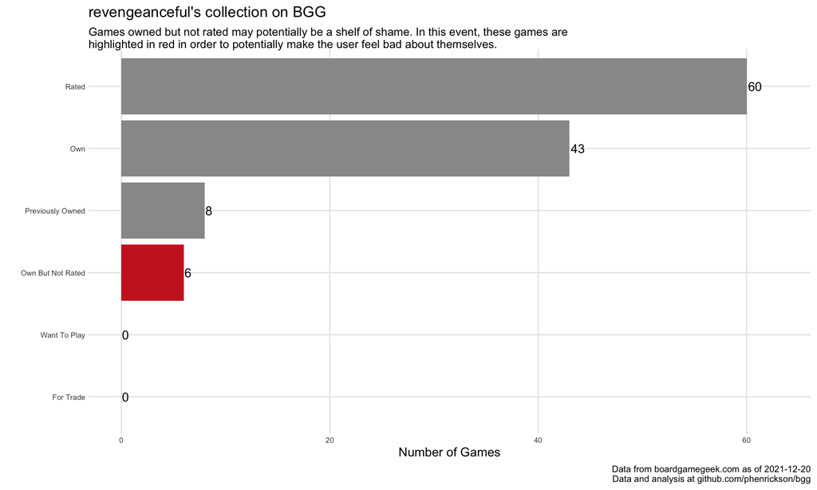

What years has the user owned/rated games from? While we can’t see when a user added or removed a game from their collection, we can look at their collection by the years in which their games were published.

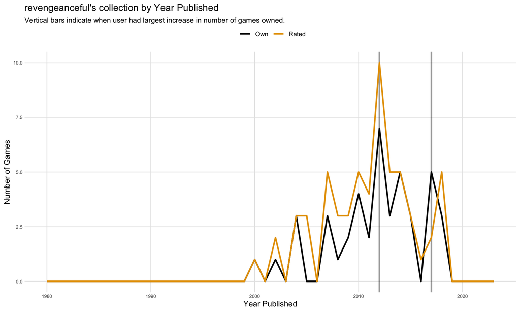

## 1.1 What types of games does revengeanceful own?

We can look at the most frequent types of categories, mechanics, designers, and artists that appear in a user’s collection.

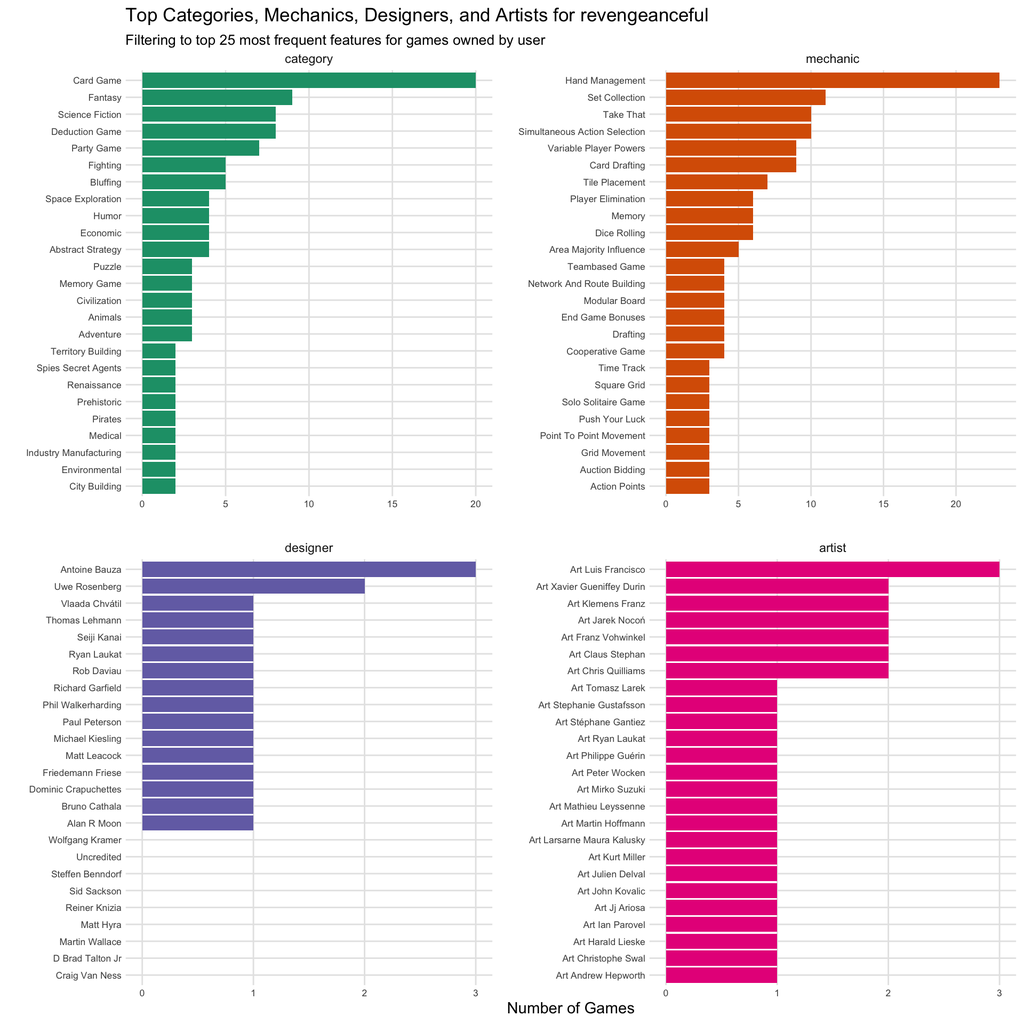

# 2 Modeling **revengeanceful’s** Collection

| username | dataset | period | games_owned | games_rated | games_played |
| --- | --- | --- | --- | --- | --- |
| revengeanceful | training | published before 2018 | 40 | 53 | 58 |
| revengeanceful | test | published 2018 or later | 3 | 5 | 6 |

There are two main (binary) outcomes we will be modeling for the user.

The first, **own** refers to whether the user currently lists a game as owned in their collection. The second, **played** refers to whether the user currently owns, has rated, or previously owned a game. This means the latter will generally have a larger list of games, but may still be a useful category to examine for people who play lots of games without necessarily owning them.

We will train predictive models to learn the probability that the user will own or play individual games based on their features.

## 2.1 Coefficients for revengeanceful

We can examine coefficients from the trained modes, which are penalized logistic regressions fit to our two main outcomes. Positive values indicate that a feature increases a user’s probabilility of owning/rating a game, while negative values indicate a feature decreases the probability.

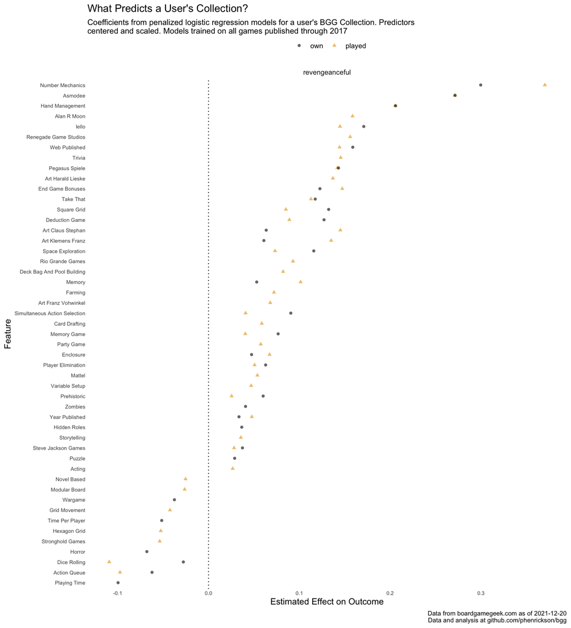

## 2.2 Visualizing Predictors for revengeanceful’s Collection

Why did the model identify these features? We can make density plots of the important features for predicting whether the user owned a game. Blue indicates the density for games owned by the user, while grey indicates the density for games not owned by the user.

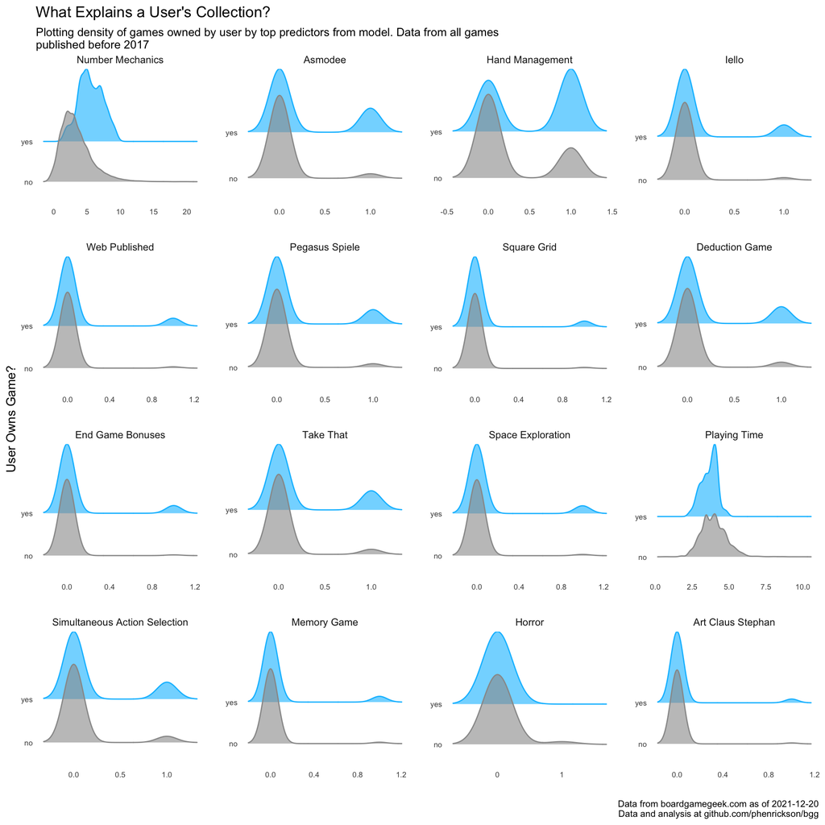

Binary predictors can be difficult to see with this visualization, so we can also directly examine the percentage of games in a user’s collection with a predictor vs the percentage of all games with that predictor.

| username | Feature | % of Games with Feature In_Collection | % of Games with Feature All_Games | Ratio |
| --- | --- | --- | --- | --- |
| revengeanceful | End Game Bonuses | 10.0% | 0.9% | 10.8 |
| revengeanceful | Communication Limits | 5.0% | 0.7% | 7.3 |
| revengeanceful | Hidden Roles | 5.0% | 0.7% | 7.1 |
| revengeanceful | Space Exploration | 10.0% | 1.6% | 6.2 |
| revengeanceful | Web Published | 10.0% | 1.7% | 5.9 |
| revengeanceful | Asmodee | 27.5% | 5.1% | 5.4 |
| revengeanceful | Prehistoric | 5.0% | 0.9% | 5.4 |
| revengeanceful | Square Grid | 7.5% | 1.4% | 5.3 |
| revengeanceful | Iello | 15.0% | 2.9% | 5.1 |
| revengeanceful | Zombies | 5.0% | 1.2% | 4.1 |
| revengeanceful | Memory Game | 7.5% | 1.9% | 4.0 |
| revengeanceful | Steve Jackson Games | 5.0% | 1.2% | 4.0 |
| revengeanceful | Pegasus Spiele | 17.5% | 4.5% | 3.9 |
| revengeanceful | Take That | 22.5% | 5.9% | 3.8 |
| revengeanceful | Enclosure | 5.0% | 1.3% | 3.8 |
| revengeanceful | Memory | 15.0% | 4.1% | 3.7 |
| revengeanceful | Player Elimination | 15.0% | 4.1% | 3.6 |
| revengeanceful | Deduction Game | 20.0% | 6.0% | 3.4 |
| revengeanceful | Simultaneous Action Selection | 20.0% | 7.4% | 2.7 |
| revengeanceful | Puzzle | 7.5% | 2.8% | 2.7 |
| revengeanceful | Hand Management | 55.0% | 26.5% | 2.1 |
| revengeanceful | Dice Rolling | 15.0% | 28.8% | 0.5 |
| revengeanceful | Horror | 0.0% | 3.7% | 0.0 |
| revengeanceful | Action Queue | 0.0% | 2.3% | 0.0 |
| revengeanceful | Wargame | 0.0% | 13.4% | 0.0 |

# 3 Assess Model’s Performance on Training Set

Before predicting games in upcoming years, we can examine how well the model did and what games it liked in the training set. In this case, we used resampling techniques (cross validation) to ensure that the model had not seen a game before making its predictions.

## 3.1 Separation Plot

An easy way to examine the performance of classification model is to view a separation plot. We plot the predicted probabilities from the model for every game (from resampling) from lowest to highest. We then overlay a blue line for any game that the user does own. A good classifier is one that is able to *separate* the blue (games owned by the user) from the white (games not owned by the user), with most of the blue occurring at the highest probabilities (right side of the chart).

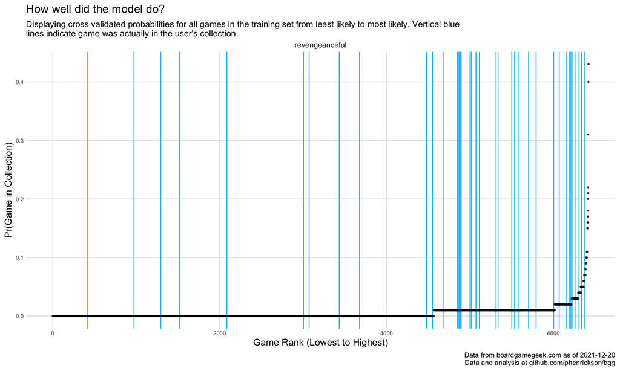

## 3.2 Top Games for **revengeanceful** from Training Set

We can display this information in table form, displaying the 100 games with the highest probability of ownership, adding a blue line when the user does own the game.

| username | yearpublished | game_id | name | pred_played | pred_own | actual_played | actual_own |
| --- | --- | --- | --- | --- | --- | --- | --- |
| revengeanceful | 2005 | 18258 | Mission: Red Planet | 0.32 | 0.43 | 0 | 0 |
| revengeanceful | 2011 | 70919 | Takenoko | 0.26 | 0.40 | 0 | 0 |
| revengeanceful | 2015 | 175878 | 504 | 0.13 | 0.31 | 0 | 0 |
| revengeanceful | 2016 | 167791 | Terraforming Mars | 0.15 | 0.22 | 0 | 0 |
| revengeanceful | 2002 | 3955 | BANG! | 0.13 | 0.21 | 0 | 0 |
| revengeanceful | 2014 | 157354 | Five Tribes | 0.12 | 0.20 | 0 | 0 |
| revengeanceful | 2015 | 175549 | Salem 1692 | 0.11 | 0.18 | 0 | 0 |
| revengeanceful | 2017 | 233078 | Twilight Imperium: Fourth Edition | 0.04 | 0.17 | 0 | 0 |
| revengeanceful | 2015 | 178900 | Codenames | 0.09 | 0.16 | 0 | 0 |
| revengeanceful | 2016 | 198773 | Codenames: Pictures | 0.09 | 0.16 | 0 | 0 |
| revengeanceful | 2016 | 182134 | Evolution: Climate | 0.09 | 0.16 | 0 | 0 |
| revengeanceful | 2016 | 177590 | 13 Days: The Cuban Missile Crisis | 0.17 | 0.15 | 0 | 0 |
| revengeanceful | 2016 | 176083 | Hit Z Road | 0.09 | 0.15 | 0 | 0 |
| revengeanceful | 2014 | 164265 | Witness | 0.08 | 0.15 | 0 | 0 |
| revengeanceful | 1968 | 7262 | Top Trumps | 0.07 | 0.15 | 0 | 0 |
| revengeanceful | 2015 | 163967 | Tiny Epic Galaxies | 0.38 | 0.15 | 0 | 0 |
| revengeanceful | 2013 | 52461 | Legacy: The Testament of Duke de Crecy | 0.23 | 0.11 | 0 | 0 |
| revengeanceful | 2010 | 62219 | Dominant Species | 0.24 | 0.11 | 0 | 0 |
| revengeanceful | 2009 | 43578 | Monster Chase | 0.02 | 0.11 | 0 | 0 |
| revengeanceful | 2014 | 132531 | Roll for the Galaxy | 0.07 | 0.11 | 0 | 0 |
| revengeanceful | 2002 | 2955 | Mexica | 0.09 | 0.10 | 0 | 0 |
| revengeanceful | 2010 | 73439 | Troyes | 0.24 | 0.10 | 0 | 0 |
| revengeanceful | 2017 | 218603 | Photosynthesis | 0.06 | 0.10 | 0 | 0 |
| revengeanceful | 2017 | 205597 | Jump Drive | 0.07 | 0.10 | 0 | 0 |
| revengeanceful | 2016 | 205158 | Codenames: Deep Undercover | 0.03 | 0.10 | 0 | 0 |
| revengeanceful | 2007 | 33495 | Time's Up! Édition purple | 0.06 | 0.10 | 0 | 0 |
| revengeanceful | 1986 | 925 | Werewolf | 0.03 | 0.10 | 0 | 0 |
| revengeanceful | 2017 | 224037 | Codenames: Duet | 0.05 | 0.09 | 0 | 0 |
| revengeanceful | 2014 | 161970 | Alchemists | 0.17 | 0.09 | 0 | 0 |
| revengeanceful | 2017 | 221805 | Breaking Bad: The Board Game | 0.11 | 0.09 | 0 | 0 |

[output cut: 70 more lines]

We can also more formally assess how well the model did in resampling by looking at the area under the receiver operating characteristic. A perfect model would receive a score of 1, while a model that cannot predict the outcome will default to a score of 0.5. The extent to which something is a *good* score depends on the setting, but generally anything in the .8 to .9 range is very good while the .7 to .8 range is perfectly acceptable.

| username | outcome_type | .metric | .estimator | .estimate |
| --- | --- | --- | --- | --- |
| revengeanceful | own | roc_auc | binary | 0.812 |
| revengeanceful | played | roc_auc | binary | 0.806 |

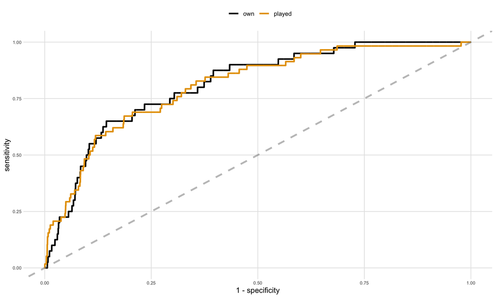

Another way to think about the model performance is to view its lift, or its ability to detect the positive outcomes over that of a null model. High lift indicates the model can much more quickly find all of the positive outcomes (in this case, games owned or played by the user), while a model with no lift is no better than random guessing.

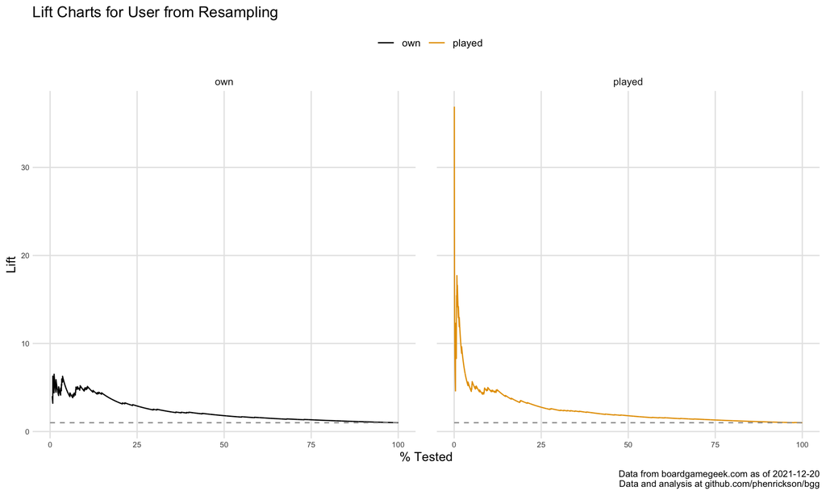

## 3.3 Most and Least Likely Games

What games does the model think revengeanceful is **most likely to own** that are **not** in their collection?

| username | yearpublished | game_id | name | pred_own | actual_own |
| --- | --- | --- | --- | --- | --- |
| revengeanceful | 2005 | 18258 | Mission: Red Planet | 0.43 | 0 |
| revengeanceful | 2011 | 70919 | Takenoko | 0.40 | 0 |
| revengeanceful | 2015 | 175878 | 504 | 0.31 | 0 |
| revengeanceful | 2016 | 167791 | Terraforming Mars | 0.22 | 0 |
| revengeanceful | 2002 | 3955 | BANG! | 0.21 | 0 |

What games does the model think revengeanceful is **least likely to own** that **are** in their collection?

| username | yearpublished | game_id | name | pred_own | actual_own |
| --- | --- | --- | --- | --- | --- |
| revengeanceful | 2012 | 119890 | Agricola: All Creatures Big and Small | 0 | 1 |
| revengeanceful | 2017 | 233371 | Clank! In! Space!: A Deck-Building Adventure | 0 | 1 |
| revengeanceful | 2015 | 161936 | Pandemic Legacy: Season 1 | 0 | 1 |
| revengeanceful | 2010 | 66587 | GOSU | 0 | 1 |
| revengeanceful | 2000 | 2453 | Blokus | 0 | 1 |

## 3.4 Top Games by Year

Top 25 games most likely to be owned by the user in each year, highlighting in blue the games that the user has owned/played.

| rank | 2009 | 2010 | 2011 | 2012 | 2013 | 2014 | 2015 | 2016 | 2017 |
| --- | --- | --- | --- | --- | --- | --- | --- | --- | --- |
| 1 | Monster Chase | Dominant Species | Takenoko | Kairo | Legacy: The Testament of Duke de Crecy | Five Tribes | 504 | Terraforming Mars | Twilight Imperium: Fourth Edition |
| 2 | Martinique | Troyes | Eclipse | Smash Up | Room 25 | Witness | Salem 1692 | Codenames: Pictures | Photosynthesis |
| 3 | EVE: Conquests | Earth Reborn | Dark Moon | Love Letter | Patchistory | Roll for the Galaxy | Codenames | Evolution: Climate | Jump Drive |
| 4 | The Werewolves of Miller's Hollow: The Village | Asteroyds | Rumble in the House | Space Cadets | Antidote | Alchemists | Tiny Epic Galaxies | 13 Days: The Cuban Missile Crisis | Codenames: Duet |
| 5 | Heartland | Castaways | Discworld: Ankh-Morpork | Il Vecchio | Lewis & Clark: The Expedition | Good Cop Bad Cop | Exploding Kittens: NSFW Deck | Hit Z Road | Breaking Bad: The Board Game |
| 6 | Dungeon Twister 2: Prison | Merchants & Marauders | Mage Knight Board Game | Archipelago | Agent Hunter | Sheriff of Nottingham | Resistor_ | Codenames: Deep Undercover | Fog of Love |
| 7 | Jaipur | 7 Wonders | Tales & Games: The Hare & the Tortoise | Suburbia | Titanium Wars | Tiny Epic Kingdoms | Blood Rage | When I Dream | Smash Up: What Were We Thinking? |
| 8 | D-Day Dice: Free Trial Version | Labyrinth: The War on Terror, 2001 – ? | Eminent Domain | Rumble in the Dungeon | Tash-Kalar: Arena of Legends | Smash Up: Science Fiction Double Feature | Burgle Bros. | Smash Up: It's Your Fault! | Pulsar 2849 |
| 9 | Small World | 51st State | A Few Acres of Snow | Targi | Cappuccino | Deception: Murder in Hong Kong | Smash Up: Munchkin | Beyond Baker Street | Spirit Island |
| 10 | Automobile | Sid Meier's Civilization: The Board Game | Ninjato | Neuroshima: Convoy | Mascarade | Smash Up: Monster Smash | Master Fox | Captain Sonar | Triplock |
| 11 | Doctor Who: Solitaire Story Game | Hanabi | Pergamon: Second Edition | Exodus: Proxima Centauri | BANG! The Dice Game | Eminent Domain: Microcosm | Watson & Holmes | Tales & Games: The Pied Piper | Space Race: The Card Game |
| 12 | Delve: The Dice Game | Commands & Colors: Napoleonics | Dungeon Fighter | Zombicide | Bomb Squad | Yardmaster Express | Exploding Kittens | Imhotep | Pandemic Legacy: Season 2 |
| 13 | The Message | Battle Cry: 150th Civil War Anniversary Edition | Power Grid: The First Sparks | The Resistance: Avalon | Circus Train (Second Edition) | Heroes of Normandie | Raptor | Dream Home | Gaia Project |
| 14 | Assyria | Spearpoint 1943 | A Game of Thrones: The Board Game (Second Edition) | Terra Mystica | Forbidden Desert | Akrotiri | Grand Austria Hotel | Kanagawa | Gloomhaven |
| 15 | Dungeon Lords | Famiglia | Panic Station | Rent a Hero | Smash Up: Awesome Level 9000 | Patchwork | Mysterium | HMS Dolores | Secrets |
| 16 | Egizia | Julius Caesar: Caesar, Pompey, and the Roman Civil War | Munchkin Axe Cop | Kemet | Smash Up: The Obligatory Cthulhu Set | Onitama | Star Realms: Colony Wars | Assembly | Codenames: Disney – Family Edition |
| 17 | Revolution! | Onirim | Kabuki | Mage Wars Arena | Eight-Minute Empire: Legends | Abyss | Haspelknecht | Love Letter Premium | This War of Mine: The Board Game |
| 18 | Zombiegeddon | Flash Duel | Ooga Booga | Mice and Mystics | Corto | Outfoxed! | Mombasa | Timebomb | Exploding Kittens: Party Pack |
| 19 | Montego Bay | Utopia Engine | Tem-Purr-A | Wiz-War (Eighth Edition) | Empire Engine | Camel Up | Bang! The Dice Game: The Walking Dead | Junta: Las Cartas | Bears vs Babies |
| 20 | The Golden City | Perplexus Epic | Nightfall | Clash of Cultures | Welcome to the Dungeon | Ultimate Werewolf | Smash Up: Pretty Pretty Smash Up | New Angeles | Smash Up: Big in Japan |
| 21 | Tobago | Escape of the Dead Minigame | Infarkt | The Big Bang Theory: The Party Game | The Phantom Society | Colt Express | Brick Party | 13 Clues | Summit: The Board Game |
| 22 | Arcana | Cyrano | Sekigahara: The Unification of Japan | Shadows over Camelot: The Card Game | Ultimate Werewolf: Inquisition | Spurs: A Tale in the Old West | Chaosmos | Honshū | Whitehall Mystery |
| 23 | Gonzaga | Reverse Charades | Space Infantry | One Night Werewolf | Tomorrow | Medieval Academy | T.I.M.E Stories | Dead of Winter: The Long Night | Stop Thief! |
| 24 | Summoner Wars | Zombie Dice | Steam Torpedo: First Contact | Munchkin Conan | Munchkin Pathfinder | Gaïa | I, Spy | Scythe | Tsukiji |
| 25 | Ra: The Dice Game | The Mines of Zavandor | Yomi | City of Horror | Hegemonic | Dead of Winter: A Crossroads Game | Harbour | Smash Up: Cease and Desist | Unstable Unicorns |

## 3.5 Interactive Predictions from Resampling

Interactive table for predictions from resampling.

|  | username | yearpublished | rank | game_id | name | pred_played | pred_own | actual_played | actual_own |
| --- | --- | --- | --- | --- | --- | --- | --- | --- | --- |
| 1 | revengeanceful | 1900 | 119 | 10799 | Old Maid | 0.04 | 0.04 | 0 | 0 |
| 2 | revengeanceful | 1900 | 177 | 5432 | Chutes and Ladders | 0.02 | 0.03 | 0 | 0 |
| 3 | revengeanceful | 1900 | 207 | 171 | Chess | 0.01 | 0.02 | 0 | 0 |
| 4 | revengeanceful | 1900 | 264 | 21389 | Happy Families | 0.01 | 0.02 | 0 | 0 |
| 5 | revengeanceful | 1900 | 334 | 45 | Perudo | 0.04 | 0.02 | 0 | 0 |
| 6 | revengeanceful | 1900 | 460 | 1602 | The Royal Game of Ur | 0.01 | 0.01 | 0 | 0 |
| 7 | revengeanceful | 1900 | 461 | 2083 | Checkers | 0.01 | 0.01 | 0 | 0 |
| 8 | revengeanceful | 1900 | 462 | 2389 | Othello | 0.02 | 0.01 | 0 | 0 |
| 9 | revengeanceful | 1900 | 514 | 10213 | Fox and Geese | 0.01 | 0.01 | 0 | 0 |
| 10 | revengeanceful | 1900 | 784 | 2173 | 4 Player Chess | 0 | 0.01 | 0 | 0 |

[output cut: 6410 more lines]

# 4 Validating the Model on 2018

How well did a model trained on a user’s collection through 2017 perform in predicting games for the user from 2018?

| username | outcome_type | yearpublished | .metric | .estimator | .estimate |
| --- | --- | --- | --- | --- | --- |
| revengeanceful | own | 2018 | roc_auc | binary | 0.649 |
| revengeanceful | played | 2018 | roc_auc | binary | 0.575 |

Table of top 25 games from 2018, highlighting games that the user owns.

| username | yearpublished | game_id | name | pred_own | pred_played | actual_own | actual_played |
| --- | --- | --- | --- | --- | --- | --- | --- |
| revengeanceful | 2018 | 205896 | Rising Sun | 0.26 | 0.52 | 0 | 0 |
| revengeanceful | 2018 | 258444 | Gingerbread House | 0.08 | 0.14 | 0 | 0 |
| revengeanceful | 2018 | 244711 | Newton | 0.06 | 0.45 | 0 | 0 |
| revengeanceful | 2018 | 256226 | Azul: Stained Glass of Sintra | 0.06 | 0.09 | 0 | 0 |
| revengeanceful | 2018 | 225694 | Decrypto | 0.05 | 0.04 | 0 | 0 |
| revengeanceful | 2018 | 232405 | Western Legends | 0.05 | 0.08 | 0 | 0 |
| revengeanceful | 2018 | 313010 | Cosmic Encounter: 42nd Anniversary Edition | 0.05 | 0.04 | 0 | 0 |
| revengeanceful | 2018 | 199792 | Everdell | 0.04 | 0.13 | 0 | 0 |
| revengeanceful | 2018 | 222219 | Kero | 0.04 | 0.06 | 0 | 0 |
| revengeanceful | 2018 | 238393 | Monolith Arena | 0.04 | 0.04 | 0 | 0 |
| revengeanceful | 2018 | 241225 | Smash Up: That '70s Expansion | 0.04 | 0.04 | 0 | 0 |
| revengeanceful | 2018 | 242302 | Space Base | 0.04 | 0.03 | 0 | 1 |
| revengeanceful | 2018 | 247724 | Smash Up: Oops, You Did It Again | 0.04 | 0.04 | 0 | 0 |
| revengeanceful | 2018 | 247763 | Underwater Cities | 0.04 | 0.11 | 0 | 0 |
| revengeanceful | 2018 | 242574 | Century: Eastern Wonders | 0.03 | 0.02 | 0 | 0 |
| revengeanceful | 2018 | 242639 | Treasure Island | 0.03 | 0.04 | 0 | 0 |
| revengeanceful | 2018 | 246297 | Shadows: Amsterdam | 0.03 | 0.04 | 0 | 0 |
| revengeanceful | 2018 | 246639 | Patchwork Express | 0.03 | 0.04 | 0 | 0 |
| revengeanceful | 2018 | 251442 | Liberation | 0.03 | 0.02 | 0 | 0 |
| revengeanceful | 2018 | 256838 | Nessos | 0.03 | 0.02 | 0 | 0 |
| revengeanceful | 2018 | 201509 | Dead Man's Doubloons | 0.02 | 0.01 | 0 | 0 |
| revengeanceful | 2018 | 207243 | The City of Kings | 0.02 | 0.02 | 0 | 0 |
| revengeanceful | 2018 | 209324 | The World of SMOG: Rise of Moloch | 0.02 | 0.02 | 0 | 0 |
| revengeanceful | 2018 | 218509 | Empires of the Void II | 0.02 | 0.02 | 0 | 0 |
| revengeanceful | 2018 | 222509 | Lords of Hellas | 0.02 | 0.04 | 0 | 0 |

# 5 Predicting Upcoming Games (2018 and On) for **revengeanceful**

Examine the top games for the test set.

| username | yearpublished | game_id | name | rank | own | played |
| --- | --- | --- | --- | --- | --- | --- |
| revengeanceful | 2018 | 205896 | Rising Sun | 1 | 0.26 | 0.52 |
| revengeanceful | 2018 | 258444 | Gingerbread House | 2 | 0.08 | 0.14 |
| revengeanceful | 2018 | 256226 | Azul: Stained Glass of Sintra | 3 | 0.06 | 0.09 |
| revengeanceful | 2018 | 244711 | Newton | 4 | 0.06 | 0.45 |
| revengeanceful | 2018 | 232405 | Western Legends | 5 | 0.05 | 0.08 |
| revengeanceful | 2018 | 313010 | Cosmic Encounter: 42nd Anniversary Edition | 6 | 0.05 | 0.04 |
| revengeanceful | 2018 | 225694 | Decrypto | 7 | 0.05 | 0.04 |
| revengeanceful | 2018 | 242302 | Space Base | 8 | 0.04 | 0.03 |
| revengeanceful | 2018 | 241225 | Smash Up: That '70s Expansion | 9 | 0.04 | 0.04 |
| revengeanceful | 2018 | 247724 | Smash Up: Oops, You Did It Again | 10 | 0.04 | 0.04 |
| revengeanceful | 2018 | 222219 | Kero | 11 | 0.04 | 0.06 |
| revengeanceful | 2018 | 247763 | Underwater Cities | 12 | 0.04 | 0.11 |
| revengeanceful | 2018 | 199792 | Everdell | 13 | 0.04 | 0.13 |
| revengeanceful | 2018 | 238393 | Monolith Arena | 14 | 0.04 | 0.04 |
| revengeanceful | 2018 | 242574 | Century: Eastern Wonders | 15 | 0.03 | 0.02 |
| revengeanceful | 2018 | 242639 | Treasure Island | 16 | 0.03 | 0.04 |
| revengeanceful | 2018 | 256838 | Nessos | 17 | 0.03 | 0.02 |
| revengeanceful | 2018 | 246639 | Patchwork Express | 18 | 0.03 | 0.04 |
| revengeanceful | 2018 | 251442 | Liberation | 19 | 0.03 | 0.02 |
| revengeanceful | 2018 | 246297 | Shadows: Amsterdam | 20 | 0.03 | 0.04 |
| revengeanceful | 2018 | 201509 | Dead Man's Doubloons | 21 | 0.02 | 0.01 |
| revengeanceful | 2018 | 233020 | Fireball Island: The Curse of Vul-Kar | 22 | 0.02 | 0.02 |
| revengeanceful | 2018 | 246759 | You've Got Crabs | 23 | 0.02 | 0.02 |
| revengeanceful | 2018 | 207243 | The City of Kings | 24 | 0.02 | 0.02 |
| revengeanceful | 2018 | 257321 | Gen7: A Crossroads Game | 25 | 0.02 | 0.02 |
| revengeanceful | 2019 | 270971 | Era: Medieval Age | 1 | 0.65 | 0.69 |
| revengeanceful | 2019 | 283863 | The Magnificent | 2 | 0.16 | 0.23 |
| revengeanceful | 2019 | 274364 | Watergate | 3 | 0.08 | 0.16 |
| revengeanceful | 2019 | 285984 | Last Bastion | 4 | 0.08 | 0.08 |
| revengeanceful | 2019 | 266507 | Clank!: Legacy – Acquisitions Incorporated | 5 | 0.07 | 0.75 |
| revengeanceful | 2019 | 276025 | Maracaibo | 6 | 0.06 | 0.19 |
| revengeanceful | 2019 | 265736 | Tiny Towns | 7 | 0.06 | 0.16 |
| revengeanceful | 2019 | 226605 | Fire Tower | 8 | 0.05 | 0.03 |
| revengeanceful | 2019 | 284083 | The Crew: The Quest for Planet Nine | 9 | 0.05 | 0.03 |
| revengeanceful | 2019 | 260710 | Amul | 10 | 0.05 | 0.07 |
| revengeanceful | 2019 | 273779 | Under Falling Skies: A 9-Card Print-and-Play Game | 11 | 0.04 | 0.03 |
| revengeanceful | 2019 | 267304 | Western Empires | 12 | 0.04 | 0.06 |
| revengeanceful | 2019 | 286096 | Tapestry | 13 | 0.04 | 0.04 |
| revengeanceful | 2019 | 274638 | Unmatched: Robin Hood vs. Bigfoot | 14 | 0.04 | 0.04 |
| revengeanceful | 2019 | 271324 | It's a Wonderful World | 15 | 0.04 | 0.07 |
| revengeanceful | 2019 | 270844 | Imperial Settlers: Empires of the North | 16 | 0.04 | 0.04 |
| revengeanceful | 2019 | 274637 | Unmatched: Battle of Legends, Volume One | 17 | 0.04 | 0.04 |
| revengeanceful | 2019 | 270970 | Century: A New World | 18 | 0.03 | 0.03 |
| revengeanceful | 2019 | 264220 | Tainted Grail: The Fall of Avalon | 19 | 0.03 | 0.08 |
| revengeanceful | 2019 | 263155 | One Key | 20 | 0.03 | 0.02 |
| revengeanceful | 2019 | 257066 | Sierra West | 21 | 0.03 | 0.07 |
| revengeanceful | 2019 | 249746 | Nanty Narking | 22 | 0.03 | 0.02 |
| revengeanceful | 2019 | 287954 | Azul: Summer Pavilion | 23 | 0.03 | 0.05 |
| revengeanceful | 2019 | 245655 | The King's Dilemma | 24 | 0.03 | 0.05 |
| revengeanceful | 2019 | 264982 | Coloma | 25 | 0.03 | 0.06 |
| revengeanceful | 2020 | 256317 | Guild Master | 1 | 0.16 | 0.25 |
| revengeanceful | 2020 | 184267 | On Mars | 2 | 0.14 | 0.20 |
| revengeanceful | 2020 | 298572 | Cosmic Encounter Duel | 3 | 0.10 | 0.07 |
| revengeanceful | 2020 | 292333 | Cowboys II: Cowboys & Indians Edition | 4 | 0.10 | 0.13 |
| revengeanceful | 2020 | 291457 | Gloomhaven: Jaws of the Lion | 5 | 0.08 | 0.06 |
| revengeanceful | 2020 | 301919 | Pandemic: Hot Zone – North America | 6 | 0.06 | 0.07 |
| revengeanceful | 2020 | 298371 | Wild Space | 7 | 0.05 | 0.07 |
| revengeanceful | 2020 | 261403 | Inhuman Conditions | 8 | 0.05 | 0.05 |
| revengeanceful | 2020 | 302840 | Carcata | 9 | 0.05 | 0.06 |
| revengeanceful | 2020 | 306735 | Under Falling Skies | 10 | 0.05 | 0.05 |
| revengeanceful | 2020 | 246900 | Eclipse: Second Dawn for the Galaxy | 11 | 0.05 | 0.05 |
| revengeanceful | 2020 | 300322 | Hallertau | 12 | 0.05 | 0.28 |
| revengeanceful | 2020 | 318183 | Prehistories | 13 | 0.04 | 0.02 |
| revengeanceful | 2020 | 325635 | Unmatched: Little Red Riding Hood vs. Beowulf | 14 | 0.04 | 0.04 |
| revengeanceful | 2020 | 236713 | Sea of Plunder | 15 | 0.04 | 0.03 |
| revengeanceful | 2020 | 245658 | Unicorn Fever | 16 | 0.03 | 0.03 |
| revengeanceful | 2020 | 256940 | Krosmaster: Blast | 17 | 0.03 | 0.03 |
| revengeanceful | 2020 | 276669 | Sensor Ghosts | 18 | 0.03 | 0.02 |
| revengeanceful | 2020 | 301767 | Mysterium Park | 19 | 0.03 | 0.03 |
| revengeanceful | 2020 | 320819 | Dinner in Paris | 20 | 0.03 | 0.04 |
| revengeanceful | 2020 | 316554 | Dune: Imperium | 21 | 0.03 | 0.07 |
| revengeanceful | 2020 | 295948 | Aqualin | 22 | 0.03 | 0.02 |
| revengeanceful | 2020 | 282922 | Windward | 23 | 0.03 | 0.02 |
| revengeanceful | 2020 | 308765 | Praga Caput Regni | 24 | 0.03 | 0.11 |
| revengeanceful | 2020 | 302310 | Nanaki | 25 | 0.03 | 0.05 |

## 5.1 Interactive Table for Upcoming Games 2018 and On

|  | username | yearpublished | game_id | name | rank | own | played |
| --- | --- | --- | --- | --- | --- | --- | --- |
| 1 | revengeanceful | 2019 | 270971 | Era: Medieval Age | 1 | 0.65 | 0.69 |
| 2 | revengeanceful | 2018 | 205896 | Rising Sun | 2 | 0.26 | 0.52 |
| 3 | revengeanceful | 2019 | 283863 | The Magnificent | 3 | 0.16 | 0.23 |
| 4 | revengeanceful | 2020 | 256317 | Guild Master | 4 | 0.16 | 0.25 |
| 5 | revengeanceful | 2020 | 184267 | On Mars | 5 | 0.14 | 0.2 |
| 6 | revengeanceful | 2020 | 298572 | Cosmic Encounter Duel | 6 | 0.1 | 0.07 |
| 7 | revengeanceful | 2020 | 292333 | Cowboys II: Cowboys &amp; Indians Edition | 7 | 0.1 | 0.13 |
| 8 | revengeanceful | 2018 | 258444 | Gingerbread House | 8 | 0.08 | 0.14 |
| 9 | revengeanceful | 2019 | 274364 | Watergate | 9 | 0.08 | 0.16 |
| 10 | revengeanceful | 2020 | 291457 | Gloomhaven: Jaws of the Lion | 10 | 0.08 | 0.06 |

[output cut: 1923 more lines]